# Assignment_3_Daniel_Rabi

```python
import numpy as np
from datascience import *
import requests
from bs4 import BeautifulSoup
import pandas as pd
from IPython.core.display import display, HTML

# These lines set up graphing capabilities.
import matplotlib
%matplotlib inline
import matplotlib.pyplot as plots
plots.style.use('fivethirtyeight')
plots.style.use('fivethirtyeight')
plots.rcParams["patch.force_edgecolor"] = True
import warnings
warnings.simplefilter('ignore', FutureWarning)
```

```python
from google.colab import drive
drive.mount('/content/drive')
```

**Functions**

```python
def display_table(table): # Converting HTML code into python and displaying it.
  display(HTML(str(table)))

def scrape_table(table): # Converting HTML tables into dataframes and then change dataframe code to datascience code.
    df = pd.read_html(str(table))
    df = pd.DataFrame(df[0])
    return Table.from_df(df)

def citation_remover(variable): # Cleans a column from citations.
  array = variable.split("[")
  return array[0]

def remove_dollar_float(price): # Removes the dollar sign from the column.
  convertedPrice = float(price.strip('$'))
  return convertedPrice

def convert_to_cad(price): # Converts USD to Canadian currency.
  converted_dollar = price * (exchangeRateAPI['rates']['CAD'])
  return round(converted_dollar,2)

def calculateppp(localgood): # Calculates the Purchase Power Parity Index.
  ppp = localgood / 3.85
  return ppp

def remove_percent_sign(percentage): # Removes the percentage sign from a column.
  first_num = percentage.split("%")
  percent = float(first_num[0]) / 100
  return percent

def capitalize(text): # Capitalizes a text.
    return text.upper()

def getExchangeRate(currency): # Converts the currency to each country's currency's code.
  converted_currency = exchangeRateAPI['rates'][currency]
  return converted_currency

def getExchangeRateCAD(currency): # Converts the currency to CAD
  converted_currency = exchangeRateAPICAD['rates'][currency]
  return converted_currency

def standard_units(arr):
    """ Converts an array to standard units """
    return (arr - np.average(arr))/np.std(arr)

def correlation(t, x, y):
    """ Computes correlation: t is a table, and x and y are column names """
    x_standard = standard_units(t.column(x))
    y_standard = standard_units(t.column(y))
    return np.average(x_standard * y_standard)
```

**Step 1**

```python
# Accessing an API to access nominal exchange rates of USD to other currencies.
endpoint = "https://api.fxratesapi.com/latest"
endpointCAD = "https://api.fxratesapi.com/latest?base=CAD"
exchangeRateAPI = requests.get(endpoint).json()
exchangeRateAPICAD = requests.get(endpointCAD).json()
print(exchangeRateAPICAD) # Used to test if the API is working.

r = requests.get("https://embed.neomam.com/big-bucks-coffee/table/")

scrapedData = BeautifulSoup(r.text, "html.parser").find_all(class_='item-line')
headers = BeautifulSoup(r.text, "html.parser").find_all(class_='table-header')

display(HTML(str(BeautifulSoup(r.text, "html.parser"))))

scrapedData[0]
```

```
{'success': True, 'terms': 'https://fxratesapi.com/legal/terms-conditions', 'privacy': 'https://fxratesapi.com/legal/privacy-policy', 'timestamp': 1734590700, 'date': '2024-12-19T06:45:00.000Z', 'base': 'CAD', 'rates': {'CAD': 1, 'ADA': 0.705781725, 'AED': 2.544607685, 'AFN': 48.575098545, 'ALL': 65…
```

What is the cost of a Starbucks Tall Latte in Every Country?

From just **$1.31** in **Turkey** and **$1.96** in **Brazil** to **$6.55** in **Denmark** and an incredible **$7.17** in **Switzerland**, the price of a simple Tall Latte from Starbucks varies around the world. How much does your Tall Latte cost, and where could you get it cheaper?

Country

Tall latte price

Price of most expensive item

**Andorra**

$3.28

N/A

**Argentina**

$4.67

$5.47

**Aruba**

$2.22

N/A

**Australia**

$3.97

$6.49

**Austria**

$3.48

$4.82

**Azerbaijan**

$3.41

N/A

**Bahamas**

$3.75

N/A

**Bahrain**

$4.24

$6.50

**Belgium**

$3.52

N/A

**Bolivia**

$3.19

$4.49

**Brazil**

$1.96

$2.94

**Bulgaria**

$2.69

$4.13

**Cambodia**

$3.25

$3.75

**Canada**

$3.85

$4.83

**Chile**

$4.95

$5.20

**China**

$4.23

$5.02

**Colombia**

$2.50

$3.50

**Costa Rica**

$4.22

$5.63

**Cyprus**

$2.97

$5.55

**Czech Republic**

$3.93

$5.70

```
<div class="item-line"><div class="country"><strong>Andorra</strong></div> <div class="price">$3.28</div> <div class="most_expensive">N/A</div></div>
```

```python
countries = []
latte_prices = []
for row in scrapedData:
    cols = row.find_all("div", class_="country")
    countries.extend([col.get_text(strip=True) for col in cols])
    cols = row.find_all("div", class_="price")
    latte_prices.extend([col.get_text(strip=True) for col in cols])
pytable = Table().with_columns("country", countries, "price of latte in USD", latte_prices)
pytable.show()
```

| country | price of latte in USD |
| --- | --- |
| Andorra | $3.28 |
| Argentina | $4.67 |
| Aruba | $2.22 |
| Australia | $3.97 |
| Austria | $3.48 |
| Azerbaijan | $3.41 |
| Bahamas | $3.75 |
| Bahrain | $4.24 |
| Belgium | $3.52 |
| Bolivia | $3.19 |
| Brazil | $1.96 |
| Bulgaria | $2.69 |
| Cambodia | $3.25 |
| Canada | $3.85 |
| Chile | $4.95 |
| China | $4.23 |
| Colombia | $2.50 |
| Costa Rica | $4.22 |
| Cyprus | $2.97 |
| Czech Republic | $3.93 |

**Step 2**

**Here we cleaning the data**

```python
coffeetable = pytable.with_columns('price of latte in USD', pytable.apply(remove_dollar_float, 'price of latte in USD'))
coffeetable = coffeetable.with_columns('price of latte in CAD', coffeetable.apply(convert_to_cad, 'price of latte in USD'), 'Purchasing Power Parity', coffeetable.apply(calculateppp, 'price of latte in USD'))

coffeetable.show()
```

| country | price of latte in USD | price of latte in CAD | Purchasing Power Parity |
| --- | --- | --- | --- |
| Andorra | 3.28 | 4.73 | 0.851948 |
| Argentina | 4.67 | 6.74 | 1.21299 |
| Aruba | 2.22 | 3.2 | 0.576623 |
| Australia | 3.97 | 5.73 | 1.03117 |
| Austria | 3.48 | 5.02 | 0.903896 |
| Azerbaijan | 3.41 | 4.92 | 0.885714 |
| Bahamas | 3.75 | 5.41 | 0.974026 |
| Bahrain | 4.24 | 6.12 | 1.1013 |
| Belgium | 3.52 | 5.08 | 0.914286 |
| Bolivia | 3.19 | 4.6 | 0.828571 |
| Brazil | 1.96 | 2.83 | 0.509091 |
| Bulgaria | 2.69 | 3.88 | 0.698701 |
| Cambodia | 3.25 | 4.69 | 0.844156 |
| Canada | 3.85 | 5.55 | 1 |
| Chile | 4.95 | 7.14 | 1.28571 |
| China | 4.23 | 6.1 | 1.0987 |
| Colombia | 2.5 | 3.61 | 0.649351 |
| Costa Rica | 4.22 | 6.09 | 1.0961 |
| Cyprus | 2.97 | 4.28 | 0.771429 |
| Czech Republic | 3.93 | 5.67 | 1.02078 |

**Step 3**

Importing Tax Data, cleaning the data, and creating a PPP Index that factors in local tax into the price.  
Brazil's and Canada's sales tax varies with location, therefore, we took the average sales tax that a consumer will pay for coffee.

```python
tax_link = requests.get("https://en.wikipedia.org/wiki/Value-added_tax#Around_the_world")
scraped_tax_data = BeautifulSoup(tax_link.text,"html.parser")


heading1 = scraped_tax_data.find("h3", {"id": "European_Union_countries"}) # Importing European Union Countrys' tax data
euro_table = heading1.find_next("table", {"class": "wikitable"})
euro_table = scrape_table(euro_table)
euro_table = euro_table.select(0, 1)

euro_table = euro_table.with_column("Standard rate (current)", euro_table.apply(citation_remover, 1))
#euro_table = euro_table.with_column("Standard rate (current)", euro_table.apply(remove_percent_sign, 1))


heading2 = scraped_tax_data.find("h3", {"id": "Non-European_Union_countries"}) # Importing non European Union Countrys' tax data
non_euro_table = heading2.find_next("table", {"class": "wikitable"})
non_euro_table = scrape_table(non_euro_table)
non_euro_table = non_euro_table.select(0, 1)


non_euro_table = non_euro_table.with_column("Country", non_euro_table.apply(citation_remover, 0))
#non_euro_table = non_euro_table.with_column("Standard rate (current)", non_euro_table.apply(remove_percent_sign, 1))

tax_table = euro_table.append(non_euro_table).sort("Country") # Combining all of the data into one table


coffee_table_tax = coffeetable.join("country", tax_table, "Country") # Joining the tax data with the coffee table
coffee_table_tax = coffee_table_tax.relabel("country", "Country").relabel("price of latte in USD", "Latte Price (USD)").relabel("price of latte in CAD", "Latte Price (CAD)").relabel("Standard rate (current)", "Sales Tax")

coffee_table_tax_array = coffee_table_tax.apply(remove_percent_sign,"Sales Tax") # Cleaning the data using a predefined function
coffee_table_tax_array[9] = 0.22 # Setting the average sales tax for Brazil
coffee_table_tax_array[12] = np.average([0.05,0.12,0.12,0.15,0.15,0.05,0.15,0.05,0.13,0.15,0.14975,0.11,0.05]) # Setting the average sales tax for Canada
coffee_table_tax = coffee_table_tax.with_column("Sales Tax", coffee_table_tax_array)

cnd_price = coffee_table_tax.where("Country", "Canada").column("Latte Price (CAD)")[0]

# Calculating PPP with tax:
coffee_table_tax = coffee_table_tax.with_column("Purchasing Power Parity With Tax", ((coffee_table_tax.column('Latte Price (CAD)') * (1 + coffee_table_tax.column("Sales Tax"))) / (cnd_price * (1 + coffee_table_tax.column("Sales Tax")))))
coffee_table_tax = coffee_table_tax.with_column("Country", coffee_table_tax.apply(capitalize, 'Country'))
coffee_table_tax.show()
```

| Country | Latte Price (USD) | Latte Price (CAD) | Purchasing Power Parity | Sales Tax | Purchasing Power Parity With Tax |
| --- | --- | --- | --- | --- | --- |
| ANDORRA | 3.28 | 4.73 | 0.851948 | 0.045 | 0.852252 |
| ARGENTINA | 4.67 | 6.74 | 1.21299 | 0.21 | 1.21441 |
| AUSTRALIA | 3.97 | 5.73 | 1.03117 | 0.1 | 1.03243 |
| AUSTRIA | 3.48 | 5.02 | 0.903896 | 0.2 | 0.904505 |
| AZERBAIJAN | 3.41 | 4.92 | 0.885714 | 0.18 | 0.886486 |
| BAHAMAS | 3.75 | 5.41 | 0.974026 | 0.12 | 0.974775 |
| BAHRAIN | 4.24 | 6.12 | 1.1013 | 0.1 | 1.1027 |
| BELGIUM | 3.52 | 5.08 | 0.914286 | 0.21 | 0.915315 |
| BOLIVIA | 3.19 | 4.6 | 0.828571 | 0.13 | 0.828829 |
| BRAZIL | 1.96 | 2.83 | 0.509091 | 0.22 | 0.50991 |
| BULGARIA | 2.69 | 3.88 | 0.698701 | 0.2 | 0.699099 |
| CAMBODIA | 3.25 | 4.69 | 0.844156 | 0.1 | 0.845045 |
| CANADA | 3.85 | 5.55 | 1 | 0.109981 | 1 |
| CHILE | 4.95 | 7.14 | 1.28571 | 0.19 | 1.28649 |
| CHINA | 4.23 | 6.1 | 1.0987 | 0.13 | 1.0991 |
| COLOMBIA | 2.5 | 3.61 | 0.649351 | 0.19 | 0.65045 |
| COSTA RICA | 4.22 | 6.09 | 1.0961 | 0.13 | 1.0973 |
| CYPRUS | 2.97 | 4.28 | 0.771429 | 0.19 | 0.771171 |
| CZECH REPUBLIC | 3.93 | 5.67 | 1.02078 | 0.21 | 1.02162 |

**Creating a bar graph to visualize the change of PPP by sales tax.**

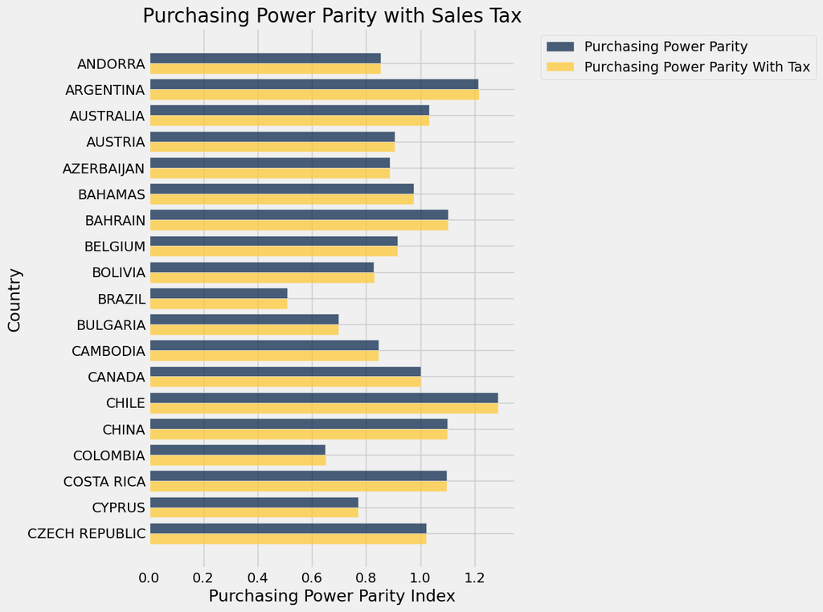

```python
coffee_table_tax.select(0, 3, 5).barh("Country")
plots.title("Purchasing Power Parity with Sales Tax")
plots.xlabel("Purchasing Power Parity Index")
```

**As we expected it does not create any change to the PPP Index**

**Step 4**

```python
currencyCodeTable = Table().read_table('/content/currency_code.csv').where('WithdrawalDate', 'nan').relabel('Entity', 'Country').select('Country', 'Currency', 'AlphabeticCode').relabel('AlphabeticCode', 'Currency Code')

coffee_table_with_currency = coffee_table_tax.join('Country', currencyCodeTable, 'Country') # Joining the currency data with the coffee table

exchange_rates = coffee_table_with_currency.apply(getExchangeRate, 'Currency Code')
coffee_table_with_currency = coffee_table_with_currency.with_column('Latte Price In Local Currency', np.round(coffee_table_with_currency.column('Latte Price (USD)') * exchange_rates, 2)).with_column("Price Difference (CAD)", coffee_table_with_currency.column("Latte Price (CAD)") - cnd_price)

coffee_table_final = coffee_table_with_currency.select('Country', 'Currency', 'Currency Code', 'Latte Price In Local Currency', 'Latte Price (CAD)', 'Sales Tax', 'Price Difference (CAD)', 'Purchasing Power Parity', 'Purchasing Power Parity With Tax')

coffee_table_final.show()
```

| Country | Currency | Currency Code | Latte Price In Local Currency | Latte Price (CAD) | Sales Tax | Price Difference (CAD) | Purchasing Power Parity | Purchasing Power Parity With Tax |
| --- | --- | --- | --- | --- | --- | --- | --- | --- |
| ANDORRA | Euro | EUR | 3.16 | 4.73 | 0.045 | -0.82 | 0.851948 | 0.852252 |
| ARGENTINA | Argentine Peso | ARS | 4767.62 | 6.74 | 0.21 | 1.19 | 1.21299 | 1.21441 |
| AUSTRALIA | Australian Dollar | AUD | 6.37 | 5.73 | 0.1 | 0.18 | 1.03117 | 1.03243 |
| AUSTRIA | Euro | EUR | 3.35 | 5.02 | 0.2 | -0.53 | 0.903896 | 0.904505 |
| AZERBAIJAN | Azerbaijan Manat | AZN | 5.8 | 4.92 | 0.18 | -0.63 | 0.885714 | 0.886486 |
| BAHAMAS | Bahamian Dollar | BSD | 3.75 | 5.41 | 0.12 | -0.14 | 0.974026 | 0.974775 |
| BAHRAIN | Bahraini Dinar | BHD | 1.59 | 6.12 | 0.1 | 0.57 | 1.1013 | 1.1027 |
| BELGIUM | Euro | EUR | 3.39 | 5.08 | 0.21 | -0.47 | 0.914286 | 0.915315 |
| BOLIVIA | Boliviano | BOB | 22.06 | 4.6 | 0.13 | -0.95 | 0.828571 | 0.828829 |
| BRAZIL | Brazilian Real | BRL | 12.31 | 2.83 | 0.22 | -2.72 | 0.509091 | 0.50991 |
| BULGARIA | Bulgarian Lev | BGN | 5.04 | 3.88 | 0.2 | -1.67 | 0.698701 | 0.699099 |
| CAMBODIA | Riel | KHR | 13036 | 4.69 | 0.1 | -0.86 | 0.844156 | 0.845045 |
| CANADA | Canadian Dollar | CAD | 5.55 | 5.55 | 0.109981 | 0 | 1 | 1 |
| CHILE | Chilean Peso | CLP | 4925.2 | 7.14 | 0.19 | 1.59 | 1.28571 | 1.28649 |
| CHINA | Yuan Renminbi | CNY | 30.88 | 6.1 | 0.13 | 0.55 | 1.0987 | 1.0991 |
| COLOMBIA | Colombian Peso | COP | 10970.5 | 3.61 | 0.19 | -1.94 | 0.649351 | 0.65045 |
| COSTA RICA | Costa Rican Colon | CRC | 2134.51 | 6.09 | 0.13 | 0.54 | 1.0961 | 1.0973 |
| CYPRUS | Euro | EUR | 2.86 | 4.28 | 0.19 | -1.27 | 0.771429 | 0.771171 |
| CZECH REPUBLIC | Czech Koruna | CZK | 95.01 | 5.67 | 0.21 | 0.12 | 1.02078 | 1.02162 |

**We will import a table for Longitude and Latitude for each Country so we can then map each country and add to each one a label of their currency.**

```python
ccll = Table.read_table("/content/country_capitals_lat_long.csv")

ccll = ccll.with_column('Country', ccll.apply(capitalize, 'Country'))
coffee_table_tax = coffee_table_tax.with_column('Country', coffee_table_tax.apply(capitalize, 'Country'))

for i in range(ccll.num_rows):
      if ccll.column("Country").item(i) == "CANADA":
        ccll["Continent"][i] = "North America"


mapping_table = coffee_table_final.join("Country", ccll, "Country").select("Country", "Currency Code", "Continent", "Capital", "Code", "Longitude", "Latitude").relabel("Code", "Country Code")
mapping_table = mapping_table.relabel("Currency Code", "labels")

def continent_colour(continent):
  if continent == "Asia":
    return "green"
  elif continent == "Europe":
    return "red"
  elif continent == "Africa":
    return "brown"
  elif continent == "North America":
    return "blue"
  elif continent == "South America":
    return "orange"
  elif continent == "Australia":
    return "purple"
  else:
    return "black"

mapping_table = mapping_table.with_column("color", mapping_table.apply(continent_colour, "Continent"))

Marker.map_table(mapping_table.select('Latitude', 'Longitude', 'labels','color'))
```

Make this Notebook Trusted to load map: File -> Trust Notebook

[interactive chart not shown]

**Step 5**

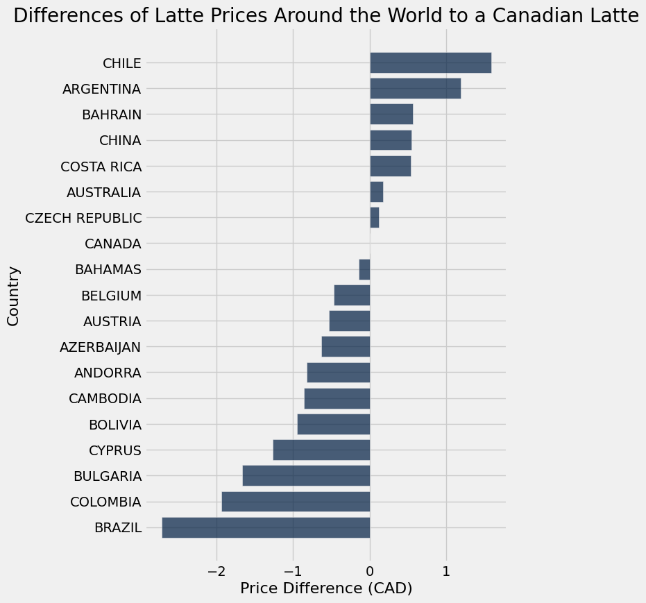

```python
coffee_table_final.sort("Price Difference (CAD)", descending=True).barh("Country", "Price Difference (CAD)")
plots.title("Differences of Latte Prices Around the World to a Canadian Latte")
```

**Step 6**

| Country | Currency | Currency Code | Latte Price In Local Currency | Latte Price (CAD) | Sales Tax | Price Difference (CAD) | Purchasing Power Parity | Purchasing Power Parity With Tax | Nominal GDP Per Capita (USD) | Nominal GDP Per Capita (CAD) | GDP difference |
| --- | --- | --- | --- | --- | --- | --- | --- | --- | --- | --- | --- |
| ANDORRA | Euro | EUR | 3.16 | 4.73 | 0.045 | -0.82 | 0.851948 | 0.852252 | 42293.3 | 61010.6 | -19191.2 |
| ARGENTINA | Argentine Peso | ARS | 4767.62 | 6.74 | 0.21 | 1.19 | 1.21299 | 1.21441 | 13867.9 | 20005.3 | -60196.5 |
| AUSTRALIA | Australian Dollar | AUD | 6.37 | 5.73 | 0.1 | 0.18 | 1.03117 | 1.03243 | 67866.8 | 97901.9 | 17700.1 |
| AUSTRIA | Euro | EUR | 3.35 | 5.02 | 0.2 | -0.53 | 0.903896 | 0.904505 | 52608.8 | 75891.3 | -4310.49 |
| AZERBAIJAN | Azerbaijan Manat | AZN | 5.8 | 4.92 | 0.18 | -0.63 | 0.885714 | 0.886486 | 7599.97 | 10963.4 | -69238.4 |
| BAHAMAS | Bahamian Dollar | BSD | 3.75 | 5.41 | 0.12 | -0.14 | 0.974026 | 0.974775 | 31458.4 | 45380.6 | -34821.2 |
| BAHRAIN | Bahraini Dinar | BHD | 1.59 | 6.12 | 0.1 | 0.57 | 1.1013 | 1.1027 | 30146.5 | 43488.2 | -36713.6 |
| BELGIUM | Euro | EUR | 3.39 | 5.08 | 0.21 | -0.47 | 0.914286 | 0.915315 | 49986.8 | 72109 | -8092.78 |
| BOLIVIA | Boliviano | BOB | 22.06 | 4.6 | 0.13 | -0.95 | 0.828571 | 0.828829 | 3600.12 | 5193.39 | -75008.4 |
| BRAZIL | Brazilian Real | BRL | 12.31 | 2.83 | 0.22 | -2.72 | 0.509091 | 0.50991 | 8917.67 | 12864.3 | -67337.5 |
| BULGARIA | Bulgarian Lev | BGN | 5.04 | 3.88 | 0.2 | -1.67 | 0.698701 | 0.699099 | 13301.9 | 19188.8 | -61013 |
| CAMBODIA | Riel | KHR | 13036 | 4.69 | 0.1 | -0.86 | 0.844156 | 0.845045 | 1759.61 | 2538.34 | -77663.4 |
| CANADA | Canadian Dollar | CAD | 5.55 | 5.55 | 0.109981 | 0 | 1 | 1 | 55596.8 | 80201.8 | 0 |
| CHILE | Chilean Peso | CLP | 4925.2 | 7.14 | 0.19 | 1.59 | 1.28571 | 1.28649 | 15338.2 | 22126.3 | -58075.5 |
| CHINA | Yuan Renminbi | CNY | 30.88 | 6.1 | 0.13 | 0.55 | 1.0987 | 1.0991 | 12597.9 | 18173.2 | -62028.6 |
| COLOMBIA | Colombian Peso | COP | 10970.5 | 3.61 | 0.19 | -1.94 | 0.649351 | 0.65045 | 6630.28 | 9564.58 | -70637.2 |
| COSTA RICA | Costa Rican Colon | CRC | 2134.51 | 6.09 | 0.13 | 0.54 | 1.0961 | 1.0973 | 13198.8 | 19040.1 | -61161.7 |
| CYPRUS | Euro | EUR | 2.86 | 4.28 | 0.19 | -1.27 | 0.771429 | 0.771171 | 32999.4 | 47603.6 | -32598.2 |
| CZECH REPUBLIC | Czech Koruna | CZK | 95.01 | 5.67 | 0.21 | 0.12 | 1.02078 | 1.02162 | 27685.1 | 39937.5 | -40264.3 |

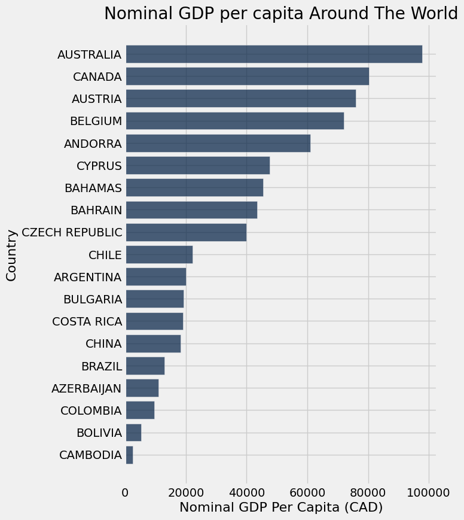

```python
gdp_data_usd_per_capita = Table().read_table('/content/gdppercapita.csv').drop('Year', 'Unit')
gdp_data_usd_per_capita = gdp_data_usd_per_capita.with_column('Country/Area', gdp_data_usd_per_capita.apply(capitalize, 'Country/Area'))
gdp_data_usd_per_capita = gdp_data_usd_per_capita.where('Country/Area', coffee_table_final.column('Country')).sort('GDP, Per Capita GDP - US Dollars', descending = False)
gdp_data_usd_per_capita = gdp_data_usd_per_capita.with_column('GDP, Per Capita GDP - Canadian Dollars', gdp_data_usd_per_capita.apply(convert_to_cad,'GDP, Per Capita GDP - US Dollars'))

coffee_table_gdp =  coffee_table_final.join('Country', gdp_data_usd_per_capita, 'Country/Area')
coffee_table_gdp = coffee_table_gdp.with_column('GDP difference', coffee_table_gdp.column('GDP, Per Capita GDP - Canadian Dollars') - coffee_table_gdp.column('GDP, Per Capita GDP - Canadian Dollars')[12])

coffee_table_gdp = coffee_table_gdp.relabel("GDP, Per Capita GDP - US Dollars", "Nominal GDP Per Capita (USD)").relabel("GDP, Per Capita GDP - Canadian Dollars", "Nominal GDP Per Capita (CAD)")

coffee_table_gdp.show()


coffee_table_gdp.select('Country','Nominal GDP Per Capita (CAD)').sort('Nominal GDP Per Capita (CAD)',descending = True).barh('Country')
plots.title('Nominal GDP per capita Around The World')
```

**Step 7**

```
correlation = 0.187609320658
```

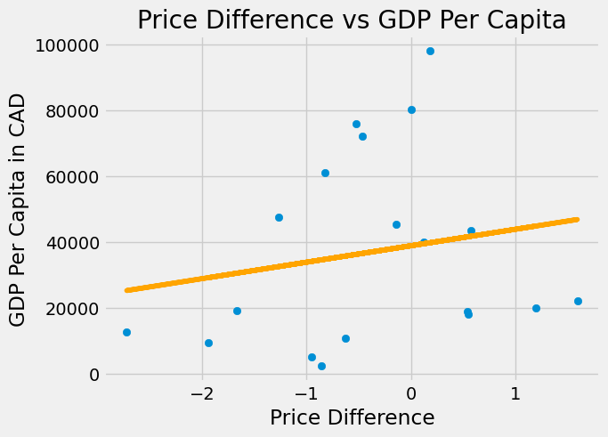

```python
coeff = np.polyfit(coffee_table_gdp.column('Price Difference (CAD)'),coffee_table_gdp.column('Nominal GDP Per Capita (CAD)'), 1)

fitted_y = np.polyval(coeff, coffee_table_gdp.column('Price Difference (CAD)'))
plots.scatter(coffee_table_gdp.column('Price Difference (CAD)'),coffee_table_gdp.column('Nominal GDP Per Capita (CAD)'))
plots.plot(coffee_table_gdp.column('Price Difference (CAD)'), fitted_y, color='orange', label='Fitted Curve')

plots.xlabel('Price Difference')
plots.ylabel('GDP Per Capita in CAD')
plots.title('Price Difference vs GDP Per Capita')

print('correlation = ' + str(correlation(coffee_table_gdp,'Price Difference (CAD)','Nominal GDP Per Capita (CAD)')))
```

Another external factor that we believe is a correlation between each country's HDI index and the differences in prices between the countries. According to Klugman et al. (2011), the HDI index measures a country based on three criteria: health, knowledge, and standard of living.

According to the United Nations Development Programme (2020):

**Very High:** HDI > 0.800  
**High:** 0.700 <= HDI <= 0.799  
**Medium:** 0.550 <= HDI < 0.700  
**Low:** HDI < 0.550

**Importing HDI Data**

```python
hdi_raw = requests.get("https://en.wikipedia.org/wiki/List_of_countries_by_Human_Development_Index?useskin=vector")
scraped_hdi = BeautifulSoup(hdi_raw.text,"html.parser")

heading_hdi = scraped_hdi.find("h2", {"id": "List"})
hdi_table = heading_hdi.find_next("table", {"class": "wikitable"})
hdi_table = scrape_table(hdi_table).select(2, 3).relabel("Country or territory", "Country")
hdi_table = hdi_table.with_column("Country", hdi_table.apply(capitalize, 'Country'))
hdi_table
```

| Country | HDI value |
| --- | --- |
| SWITZERLAND | 0.967 |
| NORWAY | 0.966 |
| ICELAND | 0.959 |
| HONG KONG | 0.956 |
| DENMARK | 0.952 |
| SWEDEN | 0.952 |
| IRELAND | 0.95 |
| GERMANY | 0.95 |
| SINGAPORE | 0.949 |
| NETHERLANDS | 0.946 |

... (183 rows omitted)

We will join the table of the price differences and the HDI values and then display the values on a bar chart to visually see the comparison.

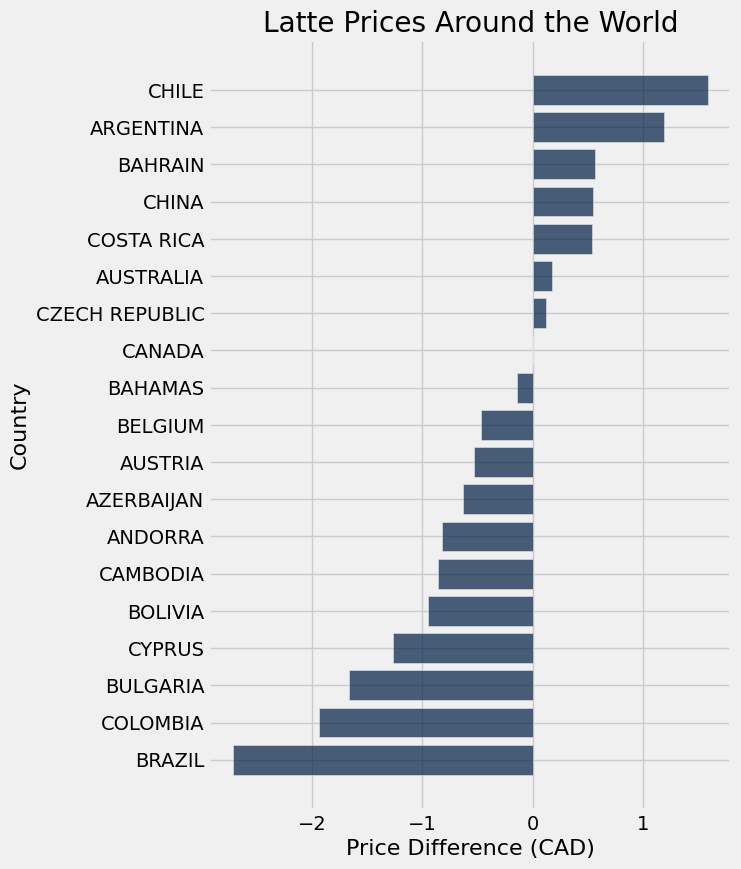

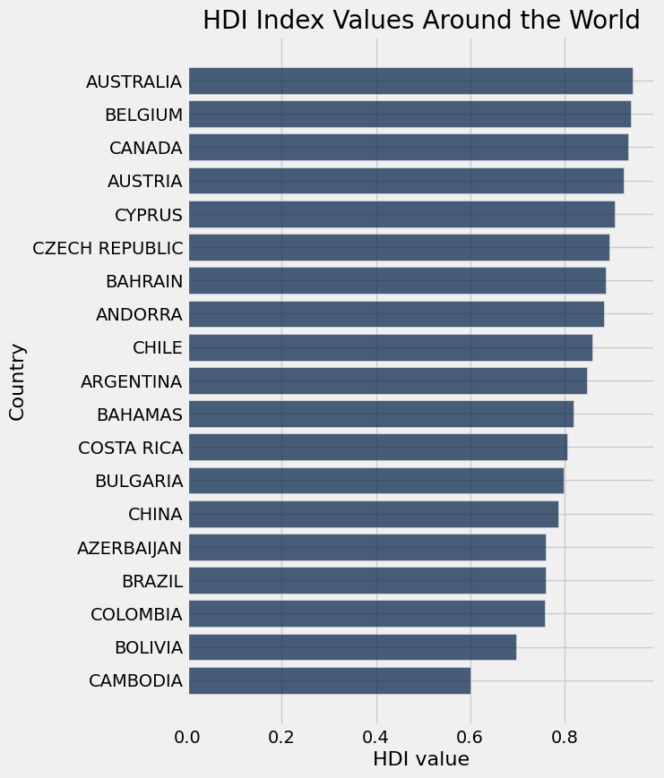

```python
price_dif_hdi = coffee_table_final.join("Country", hdi_table, "Country").sort("Price Difference (CAD)", descending=True)

price_dif_hdi = price_dif_hdi.select("Country", "Price Difference (CAD)", "HDI value")

price_dif_hdi.barh("Country", "Price Difference (CAD)")
plots.title("Latte Prices Around the World")

price_dif_hdi.sort("HDI value", descending=True).barh("Country", "HDI value")
plots.title("HDI Index Values Around the World")
```

**As a critical concept explaining the price differences in different countries, PPP is crucial in guiding investment decisions. By comparing it to the exchange rate for every currency, we can determine the potential value of the Canadian dollar. This understanding of PPP significantly enhances the sense of expertise of Starbucks executives, making them feel more knowledgeable and competent in their investment decisions, thereby boosting their confidence.**

```python
z = ("None") * coffee_table_final.num_rows

ppp_vs_exg_rate = coffee_table_final.select(0, 2, 7)
ppp_vs_exg_rate = ppp_vs_exg_rate.with_column("Exchange Rate", ppp_vs_exg_rate.apply(getExchangeRateCAD, 'Currency Code'))
ppp_vs_exg_rate = ppp_vs_exg_rate.with_column("Invest?", z)

for i in range(ppp_vs_exg_rate.num_rows):
  if ppp_vs_exg_rate.column("Purchasing Power Parity")[i] > ppp_vs_exg_rate.column("Exchange Rate")[i]:
    ppp_vs_exg_rate["Invest?"][i] = "Invest"
  else:
    ppp_vs_exg_rate["Invest?"][i] = "Don't Invest"

ppp_vs_exg_rate.show()
```

| Country | Currency Code | Purchasing Power Parity | Exchange Rate | Invest? |
| --- | --- | --- | --- | --- |
| ANDORRA | EUR | 0.851948 | 0.667078 | Invest |
| ARGENTINA | ARS | 1.21299 | 707.584 | Don't Invest |
| AUSTRALIA | AUD | 1.03117 | 1.11256 | Don't Invest |
| AUSTRIA | EUR | 0.903896 | 0.667078 | Invest |
| AZERBAIJAN | AZN | 0.885714 | 1.17826 | Don't Invest |
| BAHAMAS | BSD | 0.974026 | 0.693097 | Invest |
| BAHRAIN | BHD | 1.1013 | 0.260604 | Invest |
| BELGIUM | EUR | 0.914286 | 0.667078 | Invest |
| BOLIVIA | BOB | 0.828571 | 4.79375 | Don't Invest |
| BRAZIL | BRL | 0.509091 | 4.35469 | Don't Invest |
| BULGARIA | BGN | 0.698701 | 1.29934 | Don't Invest |
| CAMBODIA | KHR | 0.844156 | 2780.06 | Don't Invest |
| CANADA | CAD | 1 | 1 | Don't Invest |
| CHILE | CLP | 1.28571 | 689.625 | Don't Invest |
| CHINA | CNY | 1.0987 | 5.05793 | Don't Invest |
| COLOMBIA | COP | 0.649351 | 3041.45 | Don't Invest |
| COSTA RICA | CRC | 1.0961 | 350.836 | Don't Invest |
| CYPRUS | EUR | 0.771429 | 0.667078 | Invest |
| CZECH REPUBLIC | CZK | 1.02078 | 16.7554 | Don't Invest |

Now, we will map the countries where it would make sense for us to invest and display it.

```python
invest_map = ppp_vs_exg_rate.join("Country", ccll, "Country")
invest_map = invest_map.with_column("color", invest_map.apply(continent_colour, "Continent"))
invest_map = invest_map.select("Country", "Invest?", "Currency Code", "color", "Continent", "Capital", "Code", "Longitude", "Latitude").relabel("Invest?", "labels")

Marker.map_table(invest_map.select('Latitude', 'Longitude', 'labels','color'))
```

Make this Notebook Trusted to load map: File -> Trust Notebook

[interactive chart not shown]

In conclusion, Starbucks executives should consider the promising potential of investing in countries with higher PPP than exchange rates. These countries, with their lower price levels than the currency you can exchange in the bank, offer a unique opportunity. Selling coffee in these countries can yield higher returns when you convert your earnings back into Canadian dollars after the currency appreciates, presenting a hopeful outlook for your investment strategy. However, it's crucial to exercise caution. While countries with higher PPP than exchange rates may seem attractive for investment, other factors could be at play. High inflation rates or political instability, for instance, could significantly impact the value of your investments. Considering these risks before making investment decisions and fostering a sense of prudence and responsibility in your investment approach is essential.

For consumers, the prospect of visiting countries with higher PPP than exchange rates is indeed exciting. Your dollar can stretch further in these countries, allowing you to purchase more goods than in countries with a lower PPP than the exchange rate. However, it's crucial to be mindful of potential political instability when planning your visit, as this could impact your travel experience.

Ultimately, if you are a Starbucks lattes fan looking to maximize its consumption or minimize its cost, use our maps as a guide to get more of it! Similarly, our map could guide you to the right investment location if you are a Starbucks executive looking to maximize the company's ROI, instilling a sense of guidance and confidence in your decision-making process.

**References**  
Aisen, A., & Veiga, F. J., (2013). How does political instability affect economic growth?. *European Journal of Political Economy*, 29, 151-167. Klugman J., Rodríguez F., Choi HJ., (2011, January). Human development index, *World Health Organization*, https://www.who.int/data/nutrition/nlis/info/human-development-index#:~:text=The%20HDI%20is%20a%20summary,knowledge%20and%20standard%20of%20living.  
United Nations Development Programme. (2020). *Human Development Report 2019 – Technical notes.* https://web.archive.org/web/20210606201849/http://hdr.undp.org/sites/default/files/hdr2020_technical_notes.pdf.

https://www.cashnetusa.com/blog/starbucks-price-every-country/ https://en.wikipedia.org/wiki/Value-added_tax#Around_the_world https://public.opendatasoft.com/explore/dataset/currency-codes/table/ https://unstats.un.org/unsd/snaama/Basic https://en.wikipedia.org/w/index.php?title=Gross_domestic_product&useskin=vector#GDP_per_capita

```python
!jupyter nbconvert --to html drabi_a3.ipynb
```

[output not shown]

[output cut: 136 more lines]

[output not shown]